# Shrinking body size in Atlantic Forest birds as a response to climate change

Eduardo S.A. Santos

João C.T. Menezes

Gustavo Burin

11 July, 2019

# Introductory paragraph

Guidelines[^1]

Two of the main responses of organisms to climate change are phenological changes and geographical range shifts (Parmesan and Yohe 2003). Yet, a third response of organisms to global warming is increasingly being observed, the shrinkage of bodies (Celine Teplitsky and Millien 2014; Sheridan and Bickford 2011; Gardner et al. 2011). Body shrinkage due to climate change has been hypothesized to be a consequence of ecological or evolutionary processes (Ozgul et al. 2009). The ecological hypothesis posits that climate change influences trophic interactions, thus leading to a reduction in body size. Here we show that Atlantic Forest passerine birds decreased in body size over the last 28 years. The body size shrinkage is associated with both an increase in temperatures over the period as well as a large reduction in the abundance of invertebrates that serve as food resource to passerine birds. Our findings thus highlight the rapid and widespread consequences of climatic change on the availability of prey items, consequently influencing the phenotype of avian predators.

Changes in temperature can result in temperature-dependent or -independent mechanisms that influece body size (reviewed in Gardner et al. 2011). Among temperature-independent mechanisms, decreases in food availability caused by habitat loss or fragmentation may lead to the reduction of body size (Schmidt and Jensen 2005). Thus, limiting juveniles access to resources could lead to smaller adult body size (Céline Teplitsky et al. 2008; Rode, Amstrup, and Regehr 2010). Reductions in body size have been attributed to genetic microevolutionary responses to warming; smaller individuals dissipate heat better than larger individuals due to the larger ratio between surface:volume of their bodies (e.g., Bergmann’s rule, Celine Teplitsky and Millien 2014).[^2]

# Methods

## Load libraries

Here are all the libraries that we used for data wrangling, plotting and model building.

```r
library("tidyverse")
library("ggthemes")
library("brms")
library("lme4")
library("ape")
library("geiger")
library("MCMCglmm")
library("mice")
library("tidybayes")
library("reshape2")
library("data.table")
library('metafor')
```

## Load data

We used the Atlantic Bird Traits (R. C. Rodrigues et al. 2019) dataset as a source of information upon which to address our hypothesis.

```r
birds <- read_csv("ATLANTIC_BIRD_TRAITS_completed_2018_11_d05.csv", guess_max = 70000)
```

Import Elton traits (Wilman et al. 2014) dataset.

```r
elton <- read_tsv("BirdFuncDat.txt")
```

## Data wrangling and new variables

Subsetting the original dataframe into sets to explore.

We restricted our data collection to the order Passeriformes, as passerine birds represent over 82% of the entries in the Atlantic Bird Traits dataset (60,066 entries of a total of 72,483). We restricted our data to individuals that were recorded as adults during the original data collection (n = 43,149). We used records of individuals that were collected/recorded between 1990 and 2018, which yielded a total of 40,183 passerine entries. We only kept records of species that have at least 50 entries in the dataset. The sample size per species inclusion criteria reduced the dataset from 435 passerine species to 143 species. The last wrangling step was to remove all individuals that were not sexed in the original dataset, leaving a total of 68 passerine bird species for analyses. Using only records that were registed within the 20 km buffer polygon for the Atlantic Forest domain.

We chose as our metric of body size the variable wing length (mm). We decided to use wing length over other available variables from the original dataset because wing length was the the body size estimate with the least amount of missing data for the 68 passerine species. In the original dataset, wing length was provided as either the right or left wing, or generically, without mentions as to which wing was measured. We safely assumed that birds are bilaterally symmetric in order to coalesce all wing length values into a single variable, thus eliminating more missing values from the dataset used for analysis.

```r
passer90 <- birds %>%
          filter(Year >= 1990, Age == "Adult", Sex != "Unknown", Order == "Passeriformes", AtlanticForests_20km_Buffer == "inside the 20 km polygon") %>%
          mutate(
            conc.wing.length = coalesce(Wing_length_right.mm., Wing_length_left.mm., Wing_length.mm.), # combining all wing lengths to minimize number of NAs in dataset
            ln_conc_wing_length = log(conc.wing.length),
            ln_wing_length = log(Wing_length_right.mm.),
            scaled_lat = scale(Latitude_decimal_degrees*-1),
            scaled_yr = scale(Year),
            Binomial = gsub(" ", "_", Binomial),
            Binomial = gsub("Ceratopipra_rubrocapilla", "Pipra_rubrocapilla", Binomial),
            Binomial = gsub("Myiothlypis_leucoblephara", "Basileuterus_leucoblepharus", Binomial),
            Binomial = gsub("Myrmoderus_squamosus", "Myrmeciza_squamosa", Binomial),
            Binomial = gsub("Pyriglena_pernambucensis", "Pyriglena_leuconota", Binomial),
            Binomial = gsub("Rhopias_gularis", "Myrmotherula_gularis", Binomial),
            Binomial = gsub("Tangara_sayaca", "Thraupis_sayaca", Binomial),
            spp = Binomial # Creating variable for phylo matrix in model later
          ) %>%
          group_by(Binomial) %>%
          filter(n() >= 50) %>% # keeping only spp that have at least 50 records
            mutate(
                  min = min(Year),
                  max = max(Year),
                  range = max-min
                        ) %>%
            filter(range >= 10) # keeping only spp that range at least 10 yrs

# keeping only variables that I will use in the models:
passer90 <- passer90 %>%
              dplyr::select(spp, Binomial, Sex, Year, scaled_yr, Annual_mean_temperature, Latitude_decimal_degrees, scaled_lat, Longitude_decimal_degrees, Wing_length_right.mm.,ln_wing_length,conc.wing.length,ln_conc_wing_length,Bill_width.mm.)

passer90 <- as.data.frame(passer90)

# Inserting diet into passer90 dataframe:
elton$Scientific = gsub(" ", "_", elton$Scientific)
passer90$Diet <- elton$`Diet-5Cat`[match(passer90$spp, elton$Scientific)]

passer90$scaled_lat <- as.numeric(passer90$scaled_lat)
passer90$scaled_yr <- as.numeric(passer90$scaled_yr)

save(passer90, file = "passer90.rda")

rm(birds)
```

Checking the range of years per species in the *passer90* dataframe. Creating a new data frame that contains one entry per species in order to prune the phylogeny later.

```r
load("passer90.rda")

by_binomial <- group_by(passer90, Binomial)
year_range <- summarise(by_binomial,
                  min = min(Year),
                  max = max(Year),
                  range = max-min
                        )

year_range <- as.data.frame(year_range)
row.names(year_range) <- year_range$Binomial # having rows named with the species name is required for any PCM
```

Plots of the range of years per species[^4].

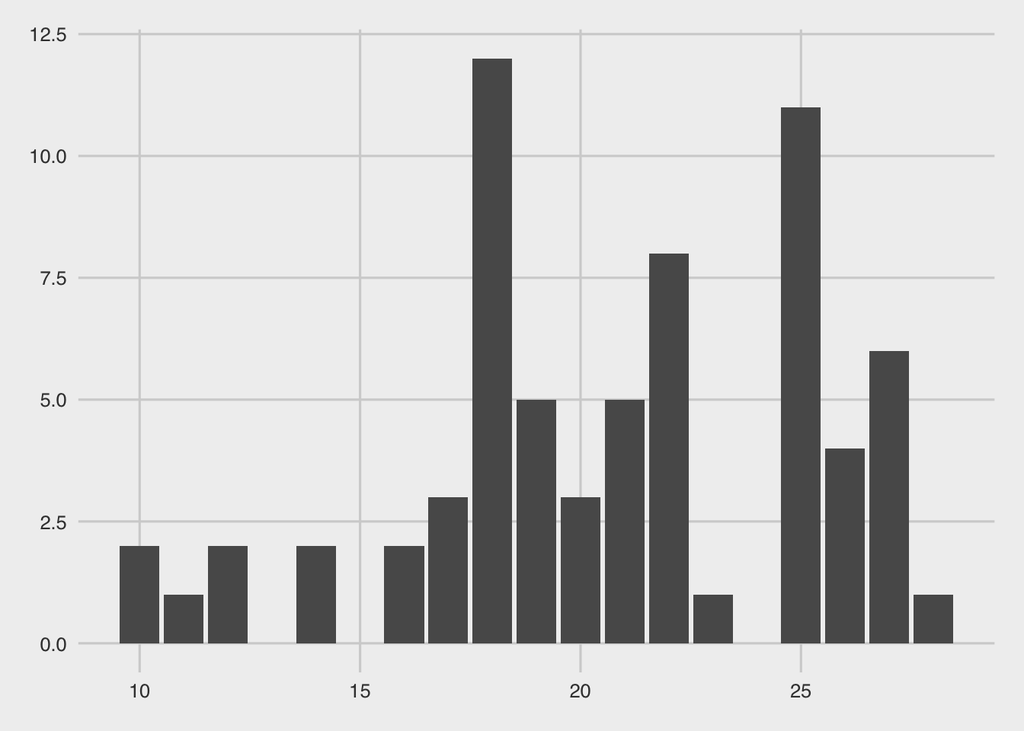

```r
g_year_range <- ggplot(data = year_range, aes(x = range)) +
                  geom_bar() +
                  theme_fivethirtyeight()

g_year_range
```

```r
summary(year_range$range)
```

```
##    Min. 1st Qu.  Median    Mean 3rd Qu.    Max.
##   10.00   18.00   21.00   20.74   25.00   28.00
```

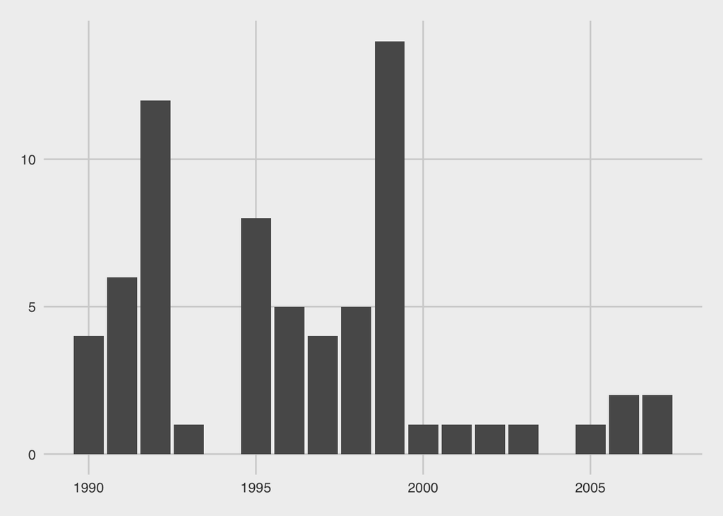

```r
g_year_min <- ggplot(data = year_range, aes(x = min)) +
                  geom_bar() +
                  theme_fivethirtyeight()
g_year_min
```

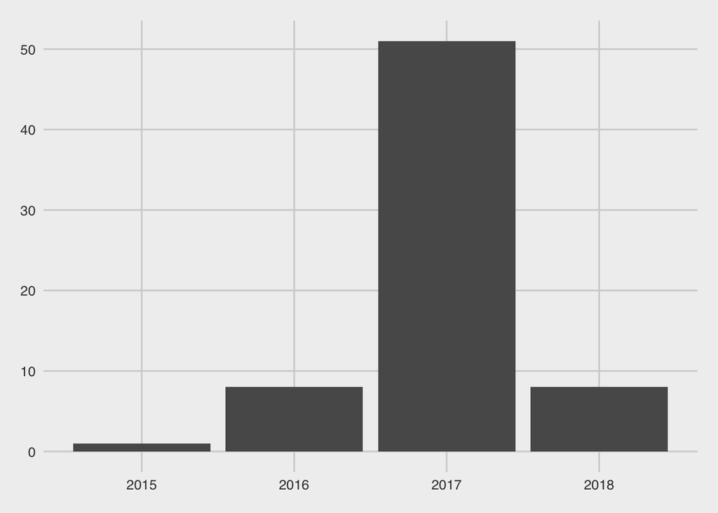

```r
g_year_max <- ggplot(data = year_range, aes(x = max)) +
                  geom_bar() +
                  theme_fivethirtyeight()
g_year_max
```

After filtering out the species with less than 10 years of data, we ended up with a total of 68 passerine species.

## Exploratory plots

Plotting some relationships:

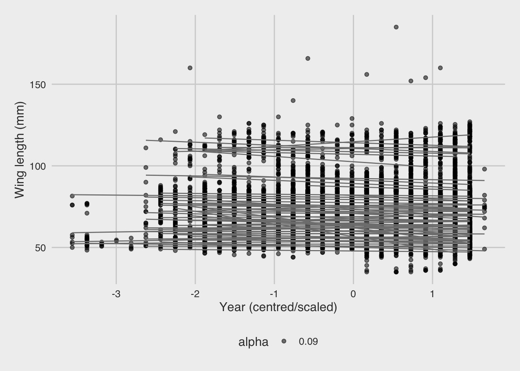

```r
g_wingl <- ggplot(data = passer90, aes(x = scaled_yr, y = conc.wing.length, group = Binomial)) +
  geom_point(aes(alpha = 0.09)) +
  stat_smooth(method = "lm", se = FALSE, colour = "grey50", size = 0.5, alpha = 0.1) +
  theme_fivethirtyeight() +
  theme(axis.title = element_text()) +
  ylab("Wing length (mm)") +
  xlab("Year (centred/scaled)")

g_wingl
```

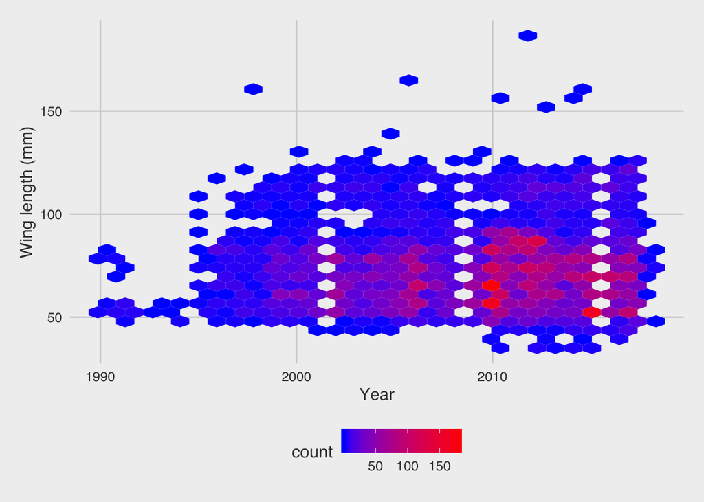

```r
pl <- ggplot(passer90, aes(x=Year,y=conc.wing.length))
pl2 <- pl + geom_hex()
print(pl2 +
        scale_fill_gradient(high = "red", low = "blue")  +
        theme_fivethirtyeight() +
        theme(axis.title = element_text()) +
        ylab("Wing length (mm)") +
        xlab("Year")
)
```

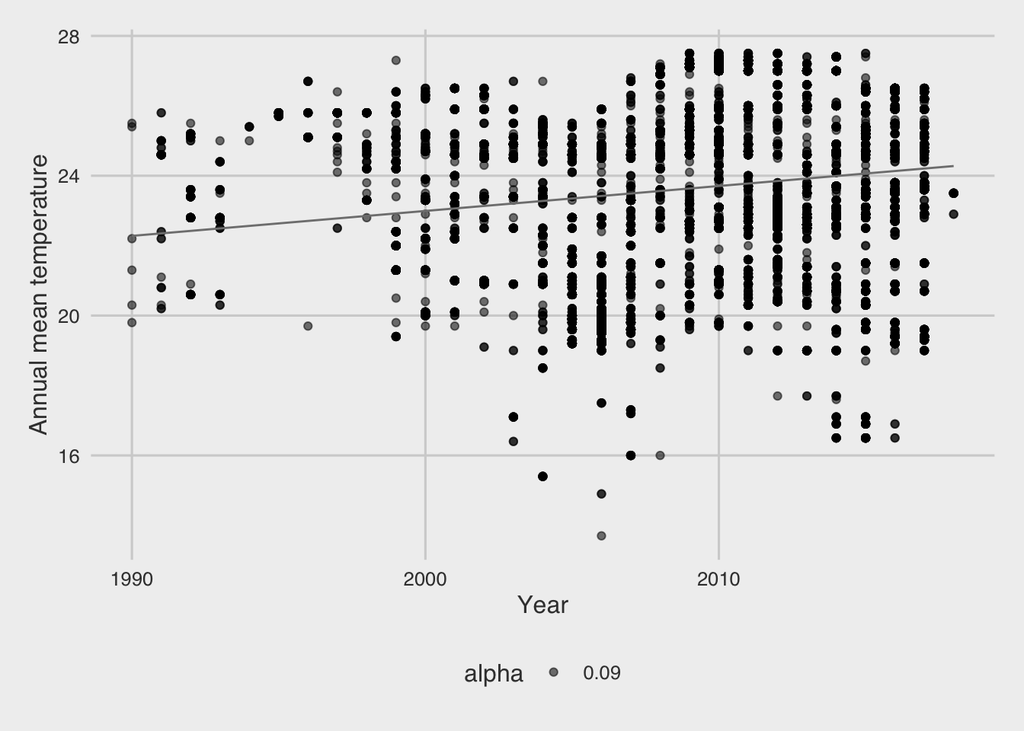

```r
g_temp <- ggplot(data = passer90, aes(x = Year, y = Annual_mean_temperature)) +
  geom_point(aes(alpha = 0.09)) +
  stat_smooth(method = "lm", se = FALSE, colour = "grey50", size = 0.5, alpha = 0.1) +
  theme_fivethirtyeight() +
  theme(axis.title = element_text()) +
  ylab("Annual mean temperature") +
  xlab("Year")

g_temp
```

# Elton traits to check bird diet

I am going to have a look at Elton Traits (Wilman et al. 2014) in order to check what is the functional diet category of the birds in our dataset. Elton traits’ metadata can be accessed through this [link](http://www.esapubs.org/archive/ecol/E095/178/metadata.php).

Filtering Elton Traits to the species in the wing length dataset:

```r
elton <- elton %>%
  mutate(Scientific = gsub(" ", "_", Scientific)
         ) %>%
  semi_join(passer90, by = c("Scientific" = "Binomial")
            ) # Keeping only the Elton traits entries that match the species in the passer90 tibble
```

Of the passerines in the **wing length** dataset, here is a breakdown of their dominant diet categories, according to the data from Elton traits:

```r
table(elton[,20])
```

```
##
##     FruiNect Invertebrate     Omnivore    PlantSeed
##           14           34           14            6
```

```r
(table(elton[,20])/68)*100
```

```
##
##     FruiNect Invertebrate     Omnivore    PlantSeed
##    20.588235    50.000000    20.588235     8.823529
```

The tables above present the counts and percetange of species, respectively, per diet category.

Only 6 species are listed in Elton Traits as having 0% of their diet consisting of invertebrates. The species that do not have any invertebrates in their diet are:

```r
cat(paste('-', elton$Scientific[which(elton$`Diet-Inv` == 0)]), sep = '\n')
```

- Euphonia_chlorotica
- Euphonia_violacea
- Coryphospingus_cucullatus
- Haplospiza_unicolor
- Sicalis_flaveola
- Tiaris_fuliginosus

All other species in the **wing length** dataset have at least some invertebrate prey as part of their diet.

# Plots

## Plotting map of sample locations

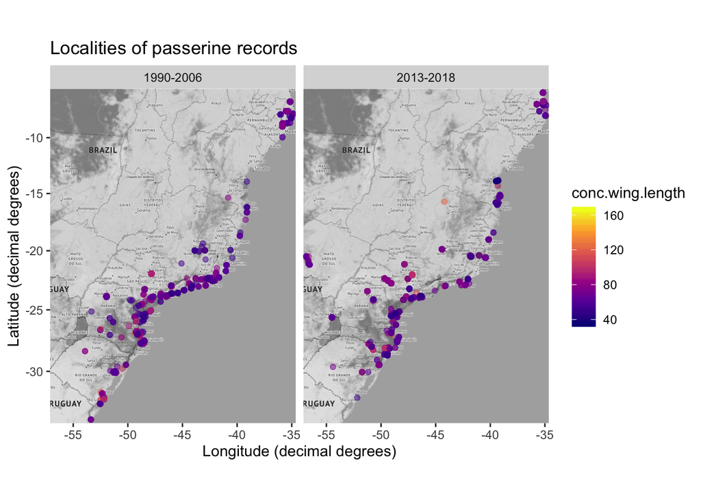

```r
library("ggmap")

bbox <- make_bbox(passer90$Longitude_decimal_degrees, passer90$Latitude_decimal_degrees, f = 0.01)
map <- get_map(bbox, source = 'osm', color = 'bw')

# I want to plot only the 1st and 3rd quartile of Years in the map:
passer.quart.years <- passer90 %>%
  filter(Year <= 2006 | Year >=2013)

passer.quart.years$period <- ifelse(passer.quart.years$Year <= 2006, '1990-2006', '2013-2018')

points <- ggmap(map) +
            geom_point(aes(x = Longitude_decimal_degrees, y = Latitude_decimal_degrees, colour = conc.wing.length), data = remove_missing(passer.quart.years, vars = "conc.wing.length"), alpha = .5) +
            scale_color_viridis_c(option = "plasma")+
            labs(title = "Localities of passerine records",
                 x = "Longitude (decimal degrees)",
                 y = "Latitude (decimal degrees)") +
            facet_wrap(~period)
points
```

## Plotting wing length and gape width trends

Plotting the trends in wing length and gape width for the birds in the dataset. I managed to estimate averages for the 1<sup>st</sup> and the 3<sup>rd</sup> quartiles. These plots are for visualization only. I will analyse the data as continuous variation.

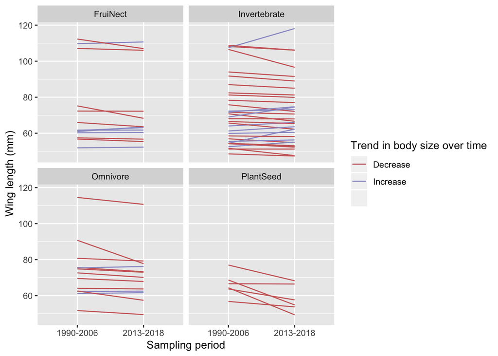

```r
# Using the quartile year dataset to plot spp mean wing lengths in the first quartile of the data and the 3rd quartile:
wing.by.spp <- passer.quart.years %>%
  group_by(spp, period) %>%
  summarise(mean.wing = mean(conc.wing.length, na.rm = TRUE),
            sd.wing = sd(conc.wing.length, na.rm = TRUE),
            sample.n.wing = n(),
            mean.bill.width = mean(Bill_width.mm., na.rm = TRUE),
            sd.bill = sd(Bill_width.mm., na.rm = TRUE)
            ) %>%
  mutate(time = ifelse(period == '1990-2006', 1, 2),
         size.trend = (mean.wing - lag(mean.wing)),
         size.trend1 = lead(size.trend),
         size.trend2 = coalesce(size.trend,size.trend1),
         wing.trend = ifelse(size.trend2 > 0, "Increase", "Decrease"),
         size.trend.bill = (mean.bill.width - lag(mean.bill.width)),
         size.trend.bill1 = lead(size.trend.bill),
         size.trend.bill2 = coalesce(size.trend.bill,size.trend.bill1),
         bill.trend = ifelse(size.trend.bill2 > 0, "Increase", "Decrease")
         )

# Inserting diet to make facets in the plots:
elton$Scientific = gsub(" ", "_", elton$Scientific)
wing.by.spp$Diet <- elton$`Diet-5Cat`[match(wing.by.spp$spp, elton$Scientific)]

# remove Antilophia (only present in 1st quartile):
wing.by.spp <- wing.by.spp[-1,]

# Creating color scheme for the slopes of the plot:
trend.wing.length <- ggplot(data = wing.by.spp, aes(x=period,y=mean.wing, group = spp, colour = size.trend2 > 0)) +
  geom_line() +
  scale_color_manual(name = "Trend in body size over time",
                     values = c("#CC6666","#9999CC"),
                     labels = c("Decrease", "Increase", "")) +
  labs(y = "Wing length (mm)",
       x = "Sampling period") +
  facet_wrap(~Diet)

trend.wing.length
```

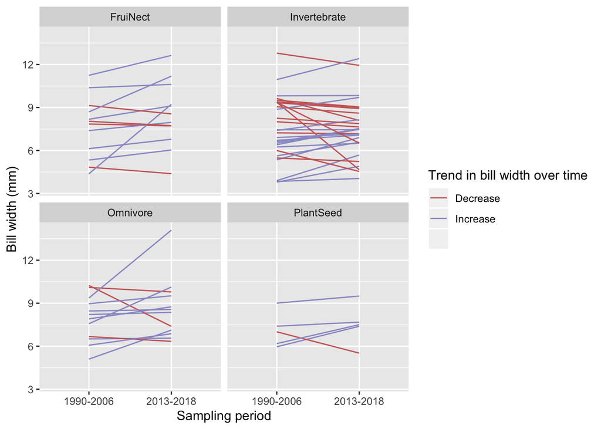

```r
trend.bill.width <- ggplot(data = wing.by.spp, aes(x=period,y=mean.bill.width, group = spp, colour = size.trend.bill2 > 0)) +
  geom_line() +
  scale_color_manual(name = "Trend in bill width over time",
                     values = c("#CC6666","#9999CC"),
                     labels = c("Decrease", "Increase", "")) +
  labs(y = "Bill width (mm)",
       x = "Sampling period") +
  facet_wrap(~Diet)

trend.bill.width
```

I plotted the average wing length for each species in the dataset for the 1<sup>st</sup> quartile (1990-2006), and the 3<sup>rd</sup> quartile (2013-2018). Each species is plotted as a trend line estimated as the difference between the average wing length in each period. Species that suffered a reduction in body size are in red and species that increase in body size between the quartiles are in blue. The number of species that decreased in body size is 47 and the number of species in which body size increased is 20.

I then investigated the trend in bill width during the same period as for wing length (described above). Species that suffered a reduction in bill width are in red and species that increase in bill width between the quartiles are in blue. The number of species that decreased in bill width is 22 and the number of species in which bill width increased is 38.

# Trend in variation of body size and gape width

Trend in variation of body size across species.

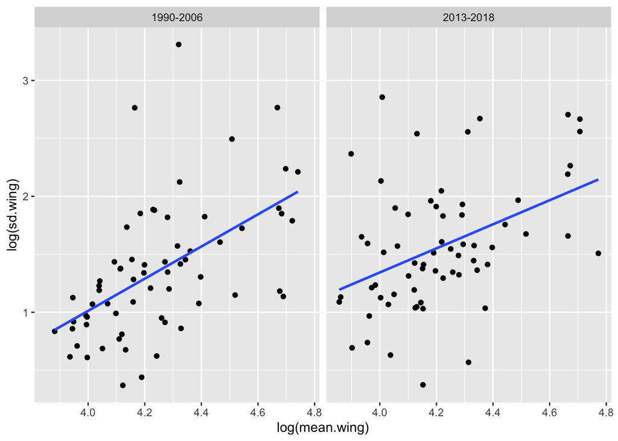

```r
### Is there a mean / sd relationship between species in wing length and bill width?
## Wing:
ggplot(wing.by.spp, aes(x=log(mean.wing), y = log(sd.wing))) +
  geom_point() +
  facet_wrap(~period) +
  stat_smooth(method = "lm", se = FALSE)
```

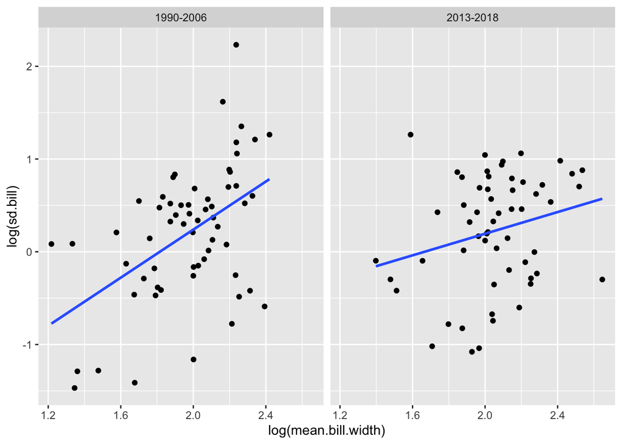

```r
## Bill:
ggplot(wing.by.spp, aes(x=log(mean.bill.width), y = log(sd.bill))) +
  geom_point() +
  facet_wrap(~period) +
  stat_smooth(method = "lm", se = FALSE)
```

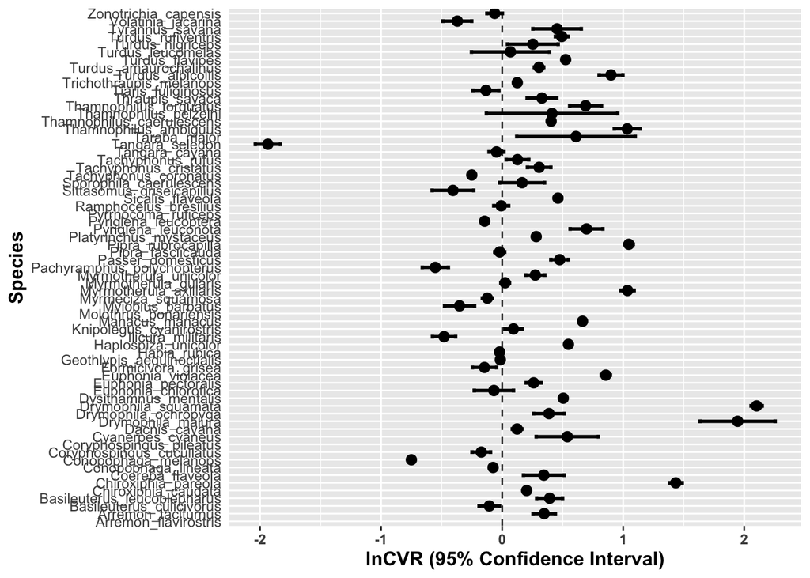

```r
### The log of the coefficient of variance ratio (lnCVR) and its sampling variance (s2lnCVR; Table 2), which assumes there is a linear relationship between the mean and variance on the natural scale (note Taylor’s Law predicts a power relationship on the natural scale).

# First transform long tibble to wide:
dat.lnCVR <- dcast(setDT(wing.by.spp),
                   spp + Diet + wing.trend + bill.trend ~ period,
                   value.var = c("mean.wing", 'sd.wing', 'mean.bill.width', 'sd.bill','sample.n.wing')
           )

#lnCVR. Here I will treat as the 'E' in the formula data from the 3rd quartile, and as 'C' data from the 1st quartile. Positive effect sizes mean that birds from the 3rd quartile have more variable body size:
dat.lnCVR$lnCVR.wing <- log((dat.lnCVR$`sd.wing_2013-2018`/dat.lnCVR$`mean.wing_2013-2018`)/(dat.lnCVR$`sd.wing_1990-2006`/dat.lnCVR$`mean.wing_1990-2006`)) + (1/(2*(dat.lnCVR$`sample.n.wing_2013-2018`-1))) - (1/(2*(dat.lnCVR$`sample.n.wing_1990-2006`-1)))

# To estimate s2.lnCVR I need a correlation across bird species of the log (ln) mean and log sd:
cor.wing.1990.2006 <- cor(log(wing.by.spp$mean.wing[wing.by.spp$period == "1990-2006"]), log(wing.by.spp$sd.wing[wing.by.spp$period == "1990-2006"]), use = "complete.obs")

cor.wing.2013.2018 <- cor(log(wing.by.spp$mean.wing[wing.by.spp$period == "2013-2018"]), log(wing.by.spp$sd.wing[wing.by.spp$period == "2013-2018"]), use = "complete.obs")

s2.lnCVR <- function(mean.c, sd.c, n.c, cor.c, mean.e, sd.e, n.e, cor.e){
  a.c = (sd.c^2)/((n.c)*mean.c^2)
  b.c = 1/(2*(n.c-1))
  c.c = 2*cor.c*(sqrt(a.c*b.c))

  a.e = (sd.e^2)/((n.e)*mean.e^2)
  b.e = 1/(2*(n.e-1))
  c.e = 2*cor.e*(sqrt(a.e*b.e))

  return(a.c + b.c - c.c + a.e + b.e - c.e)
}

dat.lnCVR$s2.lnCVR.wing <- s2.lnCVR(dat.lnCVR$`mean.wing_1990-2006`,dat.lnCVR$`sd.wing_1990-2006`,dat.lnCVR$`sample.n.wing_1990-2006`,cor.wing.1990.2006,dat.lnCVR$`mean.wing_2013-2018`,dat.lnCVR$`sd.wing_2013-2018`,dat.lnCVR$`sample.n.wing_2013-2018`,cor.wing.2013.2018)

dat.lnCVR$lci.wing <- dat.lnCVR$lnCVR.wing - 1.96*dat.lnCVR$s2.lnCVR.wing
dat.lnCVR$uci.wing <- dat.lnCVR$lnCVR.wing + 1.96*dat.lnCVR$s2.lnCVR.wing

# Plot forest plot of effect sizes and 95% CIs:
p <- ggplot(data=dat.lnCVR,
           aes(x = spp,y = lnCVR.wing, ymin = lci.wing, ymax = uci.wing)
           ) +
  geom_pointrange()+
  geom_hline(yintercept =0, linetype=2)+
  xlab('Species') +
  ylab("lnCVR (95% Confidence Interval)")+
  geom_errorbar(aes(ymin=lci.wing, ymax=uci.wing),width=0.5,cex=1)+
  theme(plot.title=element_text(size=16,face="bold"),
        axis.ticks.y=element_blank(),
        axis.text.x=element_text(face="bold"),
        axis.title=element_text(size=12,face="bold"),
        strip.text.y = element_text(hjust=0,vjust = 1,angle=180,face="bold"))+
  coord_flip()

p
```

```r
# Running quick meta-analysis of lnCVR of wing length:
metareg <- rma(yi = lnCVR.wing, vi = s2.lnCVR.wing, method = "REML", data = dat.lnCVR)
summary(metareg)
```

```
##
## Random-Effects Model (k = 63; tau^2 estimator: REML)
##
##   logLik  deviance       AIC       BIC      AICc
## -55.2559  110.5118  114.5118  118.7661  114.7152
##
## tau^2 (estimated amount of total heterogeneity): 0.2989 (SE = 0.0612)
## tau (square root of estimated tau^2 value):      0.5468
## I^2 (total heterogeneity / total variability):   94.60%
## H^2 (total variability / sampling variability):  18.51
##
## Test for Heterogeneity:
## Q(df = 62) = 795.6762, p-val < .0001
##
## Model Results:
##
## estimate      se    zval    pval   ci.lb   ci.ub
##   0.2471  0.0738  3.3481  0.0008  0.1024  0.3917  ***
##
## ---
## Signif. codes:  0 '***' 0.001 '**' 0.01 '*' 0.05 '.' 0.1 ' ' 1
```

```r
# The results of this quick meta-analysis suggest that despite the overall decline in body size, the more recently sampled birds present more variability in body size than the birds that were sampled between 1990 and 2006. This is indicated by the positive lnCVR mean meta-analytic effect size.
```

Trend in variation in bill width across bird species.

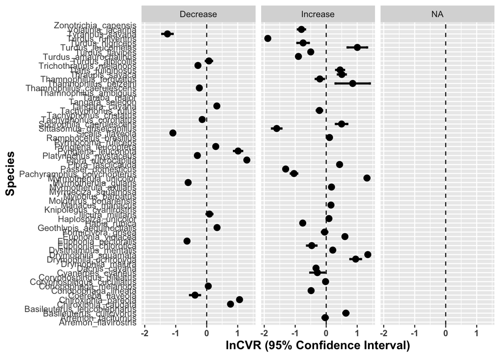

```r
### Here is the same analysis for bill width:
#lnCVR. Here I will treat as the 'E' in the formula data from the 3rd quartile, and as 'C' data from the 1st quartile. Positive effect sizes mean that birds from the 3rd quartile have more variable bill width:
dat.lnCVR$lnCVR.bill <- log((dat.lnCVR$`sd.bill_2013-2018` /dat.lnCVR$`mean.bill.width_2013-2018`)/(dat.lnCVR$`sd.bill_1990-2006` /dat.lnCVR$`mean.bill.width_1990-2006`)) + (1/(2*(dat.lnCVR$`sample.n.wing_2013-2018`-1))) - (1/(2*(dat.lnCVR$`sample.n.wing_1990-2006`-1)))

# To estimate s2.lnCVR I need a correlation across bird species of the log (ln) mean and log sd:
cor.bill.1990.2006 <- cor(log(wing.by.spp$mean.bill.width[wing.by.spp$period == "1990-2006"]), log(wing.by.spp$sd.bill[wing.by.spp$period == "1990-2006"]), use = "complete.obs")

cor.bill.2013.2018 <- cor(log(wing.by.spp$mean.bill.width[wing.by.spp$period == "2013-2018"]), log(wing.by.spp$sd.bill[wing.by.spp$period == "2013-2018"]), use = "complete.obs")

dat.lnCVR$s2.lnCVR.bill <- s2.lnCVR(dat.lnCVR$`mean.bill.width_1990-2006`,dat.lnCVR$`sd.bill_1990-2006`,dat.lnCVR$`sample.n.wing_1990-2006`,cor.bill.1990.2006,dat.lnCVR$`mean.bill.width_2013-2018`,dat.lnCVR$`sd.bill_2013-2018`,dat.lnCVR$`sample.n.wing_2013-2018`,cor.bill.2013.2018)

dat.lnCVR$lci.bill <- dat.lnCVR$lnCVR.bill - 1.96*dat.lnCVR$s2.lnCVR.bill
dat.lnCVR$uci.bill <- dat.lnCVR$lnCVR.bill + 1.96*dat.lnCVR$s2.lnCVR.bill

# Plot forest plot of effect sizes and 95% CIs:
p1 <- ggplot(data=dat.lnCVR,
           aes(x = spp,y = lnCVR.bill, ymin = lci.bill, ymax = uci.bill)
) +
  geom_pointrange()+
  geom_hline(yintercept =0, linetype=2)+
  xlab('Species') +
  ylab("lnCVR (95% Confidence Interval)")+
  geom_errorbar(aes(ymin=lci.bill, ymax=uci.bill),width=0.5,cex=1)+
  theme(plot.title=element_text(size=16,face="bold"),
        axis.ticks.y=element_blank(),
        axis.text.x=element_text(face="bold"),
        axis.title=element_text(size=12,face="bold"),
        strip.text.y = element_text(hjust=0,vjust = 1,angle=180,face="bold")) +
  facet_wrap(~bill.trend) +
  coord_flip()

p1
```

```r
# Running quick meta-analysis of lnCVR of bill width:
metareg1 <- rma(yi = lnCVR.bill, vi = s2.lnCVR.bill, method = "REML", data = dat.lnCVR)
summary(metareg1)
```

```
##
## Random-Effects Model (k = 53; tau^2 estimator: REML)
##
##   logLik  deviance       AIC       BIC      AICc
## -58.2947  116.5893  120.5893  124.4918  120.8342
##
## tau^2 (estimated amount of total heterogeneity): 0.5035 (SE = 0.1065)
## tau (square root of estimated tau^2 value):      0.7096
## I^2 (total heterogeneity / total variability):   97.14%
## H^2 (total variability / sampling variability):  34.97
##
## Test for Heterogeneity:
## Q(df = 52) = 1265.7263, p-val < .0001
##
## Model Results:
##
## estimate      se     zval    pval    ci.lb   ci.ub
##  -0.0426  0.1013  -0.4206  0.6741  -0.2413  0.1560
##
## ---
## Signif. codes:  0 '***' 0.001 '**' 0.01 '*' 0.05 '.' 0.1 ' ' 1
```

```r
# The results of this quick meta-analysis suggest that despite the overall increase in bill width, the variability in bill width is similar in birds that were sampled in the first and the third quartile of the sampling period. This is indicated by the lnCVR mean meta-analytic effect size close to 0. Thus, there is no detectable trend in the variation of bill width across species.
```

# Models

## lmer (quick) models

```r
m0 <- lmer(Wing_length_right.mm. ~ scaled_yr + Sex + scaled_lat + scaled_yr*Diet + (1 + scaled_yr | Binomial),
           data = passer90,
           REML = FALSE,
           control = lmerControl(optimizer ="Nelder_Mead")
           )

summary(m0)

m1 <- lmer(Bill_width.mm. ~ scaled_yr + scaled_lat + scaled_yr*Diet + (1 + scaled_yr | Binomial),
           data = passer90,
           REML = FALSE,
           control = lmerControl(optimizer ="Nelder_Mead")
           )

summary(m1)
```

## Loading the phylogeny

Loading phylogeny to include in the multi-level model. For all analyses, we used species-level Passeriformes trees taken from a sample of 1,000 topologies based on the Hackett backbone from Jetz et al.’s (2012) [BirdTree.org](http://birdtree.org). We will later prune these 5,966-species trees to fit the species in each analyses for which we have succesfully collected complete data.

The chunk to load the phylogeny will only be evaluated in the local version of the code, to save time and space when in version control.

```r
trees <- read.nexus("Hackett_trees.nex")
```

Chunk to process and save a sample of 50 trees:

```r
namecheck_passer <- name.check(trees[[1]], year_range) # checking which species are in the phylogeny but not in our data frame

# namecheck_subset <- namecheck_passer$tree_not_data[grep("Thraupis", namecheck_passer$tree_not_data)] # Code to check if the species is available in the phylogeny under a different (synonim) genus name.

tree_samp <- sample(trees, size = 50) # Sampling 50 trees from the 1000 file. This is enough for the phylogenetic uncertainty.

trees_passer <- lapply(tree_samp, drop.tip, namecheck_passer$tree_not_data) # pruning these species from all the 50 trees

class(trees_passer) <- "multiPhylo"

nrow(year_range) # number of species for which we have complete data
length(trees_passer[[1]]$tip.label) # number of tips in the phylogenic trees

save(trees_passer, file = "trees_passer.rda")


rm(list = c("trees", "year_range", "by_binomial", "tree_samp", "namecheck_passer")) # remove objects that aren't needed anymore
```

Load multiphylo file with 50 sampled trees:

```r
# The phylo object contains information on the relationship between species. Using this information, we can construct a covariance matrix of species.
load("trees_passer.rda")
inv.phylo <- inverseA(trees_passer[[1]], nodes = "TIPS", scale = TRUE)
A <- solve(inv.phylo$Ainv)
rownames(A) <- rownames(inv.phylo$Ainv)
```

## Multiple imputation wing length

Before running the multi-level Bayesian model, I will use multiple imputation to impute missing data with the package *mice*. The idea is to create 5 new datasets with fully imputed data.

```r
require(lattice)
require(pan)
require(multilevel)

# Exploring the missing data pattern:
md.pattern(passer90, rotate.names = TRUE)

histogram(~ as.numeric(as.factor(Binomial)) | is.na(conc.wing.length), data=passer90)
# We do see that the histogram for the missing wing length (TRUE) is further to the right than the histogram for observed wing length (FALSE). This would indicate a right-tailed MAR missingness.

histogram(~ as.numeric(as.factor(Binomial)) | is.na(Latitude_decimal_degrees), data=passer90)
# We do see that the histogram for the missing Latitude (TRUE) is centered on the histogram for observed Latitude (FALSE). This would indicate a non-skewed MAR missingness.

# Have a look at the intraclass correlation (ICC) for the incomplete variables: Wing length:
ICC1(aov(conc.wing.length ~ Binomial, data = passer90))

# Impute the passer90 dataset with mice using imputation method norm
ini <- mice(passer90, maxit = 0)
meth <- ini$meth
meth

meth[c(12,13)] <- "norm"
meth

pred <- ini$pred
pred

start_time <- Sys.time()
#passer90_imp <- mice(passer90, meth = meth, pred = pred, print = FALSE)
end_time <- Sys.time();end_time - start_time

# Compare the means of the variables in the first imputed dataset and in the incomplete dataset:
summary(complete(passer90_imp))

summary(passer90)

# Compare the ICC’s of the variables in the first imputed dataset with those in the incomplete dataset:
data.frame(vars = names(passer90[12]),
           observed = c(ICC1(aov(conc.wing.length ~ Binomial, passer90))
                        ),
           norm     = c(ICC1(aov(conc.wing.length ~ Binomial, complete(passer90_imp)))
                        ))

# Now impute the passer90 dataset again with mice using imputation method norm for the same variables as before, but now include Binomial as a predictor for all variables:
pred <- ini$pred
pred[, "Binomial"] <- 1
pred

start_time <- Sys.time()
#passer90_imp1 <- mice(passer90, meth = meth, pred = pred, print = FALSE)
end_time <- Sys.time();end_time - start_time

# Compare the ICC’s of the variables in the first imputed dataset with those in the incomplete dataset and the 2nd imputed set:
data.frame(vars = names(passer90[c(8, 6)]),
           observed = c(ICC1(aov(Wing_length_right.mm. ~ Binomial, passer90)),
                        ICC1(aov(Latitude_decimal_degrees ~ Binomial, passer90))
                        ),
           norm     = c(ICC1(aov(Wing_length_right.mm. ~ Binomial, complete(passer90_imp))),
                        ICC1(aov(Latitude_decimal_degrees ~ Binomial, complete(passer90_imp)))
                        ),
           normBinomial     = c(ICC1(aov(Wing_length_right.mm. ~ Binomial, complete(passer90_imp1))),
                        ICC1(aov(Latitude_decimal_degrees ~ Binomial, complete(passer90_imp1)))
                        )
           )

plot(passer90_imp1, "conc.wing.length")

# Add 10 more iterations:
#passer90_imp2 <- mice.mids(passer90_imp1, maxit = 10)

plot(passer90_imp2, "conc.wing.length")

# Add 20 more iterations:
#passer90_imp3 <- mice.mids(passer90_imp2, maxit = 20, print = FALSE)

plot(passer90_imp3, "conc.wing.length")

# Plot the densities of the observed and imputed data (use passer90_imp3) with the function densityplot().
densityplot(passer90_imp3)

# Impute the passer90 data once more where you use predictive mean matching and include all variables as predictors. Name the object passer90_imp4.
passer90_imp4 <- mice(passer90, print = FALSE)

densityplot(passer90_imp4, ~conc.wing.length)
plot(passer90_imp4)

passer90_imp4a <- mice.mids(passer90_imp4, maxit = 20, print = FALSE)
plot(passer90_imp4a)
densityplot(passer90_imp4a, ~conc.wing.length)

save(passer90_imp4a, file = "passer90_imp4a.rda")
```

### Multilevel models with imputed data and phylogeny

```r
load("passer90_imp4a.rda")

start_time <- Sys.time()
brm.imputed <- brm_multiple(conc.wing.length ~ 1 + Sex + scaled_yr + scaled_lat + (1 + scaled_yr || spp) + (1 | Binomial),
            cov_ranef = list(Binomial = A),
            data = passer90_imp4a,
            family = gaussian,
            prior = c(prior(normal(71, 15), class = Intercept),
                      prior(normal(0, 10), class = b),
                      prior(cauchy(0, 1), class = sd),
                      prior(cauchy(0, 1), class = sigma)),
            chains = 2,
            cores = 2,
            control = list(max_treedepth = 12))

end_time <- Sys.time();end_time - start_time

save(brm.imputed, file = "brm_imputed.rda")
```

## brm model of wing length

I will keep this full model here for a while. I will run the model from the chunk above as a test model with the multiple imputation data. Glauco made some comments that I have to check[^5]

```r
start_time <- Sys.time()
brm0 <- brm(conc.wing.length ~ 1 + Sex + scaled_yr + scaled_lat + (1 + scaled_yr || spp) + (1 | Binomial),
            cov_ranef = list(Binomial = A),
            data = passer90,
            family = gaussian,
            prior = c(prior(normal(71, 15), class = Intercept),
                      prior(normal(0, 10), class = b),
                      prior(cauchy(0, 1), class = sd),
                      prior(cauchy(0, 1), class = sigma)),
            iter = 1500,
            warmup = 1000,
            chains = 4,
            cores = 4,
            control = list(max_treedepth = 12))

end_time <- Sys.time();end_time - start_time

save(brm0, file = "brm0.rda")
```

Summary and model convergence checks:

```r
load("brm0.rda")

summary(brm0)
```

```
##  Family: gaussian
##   Links: mu = identity; sigma = identity
## Formula: conc.wing.length ~ 1 + Sex + scaled_yr + scaled_lat + (1 + scaled_yr || spp) + (1 | Binomial)
##    Data: passer90 (Number of observations: 9387)
## Samples: 4 chains, each with iter = 1500; warmup = 1000; thin = 1;
##          total post-warmup samples = 2000
##
## Group-Level Effects:
## ~Binomial (Number of levels: 68)
##               Estimate Est.Error l-95% CI u-95% CI Eff.Sample Rhat
## sd(Intercept)    22.92      1.94    19.44    27.05        321 1.01
##
## ~spp (Number of levels: 68)
##               Estimate Est.Error l-95% CI u-95% CI Eff.Sample Rhat
## sd(Intercept)     1.21      1.13     0.04     4.29         37 1.07
## sd(scaled_yr)     1.40      0.15     1.12     1.72        513 1.00
##
## Population-Level Effects:
##            Estimate Est.Error l-95% CI u-95% CI Eff.Sample Rhat
## Intercept     72.16      9.05    54.40    89.38        312 1.01
## SexMale        2.56      0.10     2.35     2.76       3708 1.00
## scaled_yr     -0.66      0.19    -1.03    -0.30        472 1.01
## scaled_lat    -0.43      0.10    -0.62    -0.23       3658 1.00
##
## Family Specific Parameters:
##       Estimate Est.Error l-95% CI u-95% CI Eff.Sample Rhat
## sigma     5.01      0.04     4.95     5.09       4377 1.00
##
## Samples were drawn using sampling(NUTS). For each parameter, Eff.Sample
## is a crude measure of effective sample size, and Rhat is the potential
## scale reduction factor on split chains (at convergence, Rhat = 1).
```

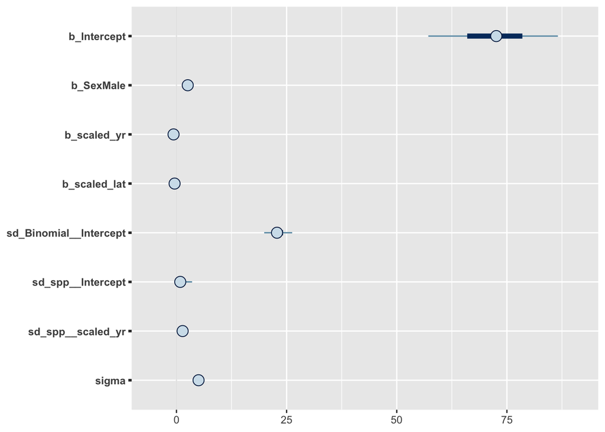

```r
stanplot(brm0)
```

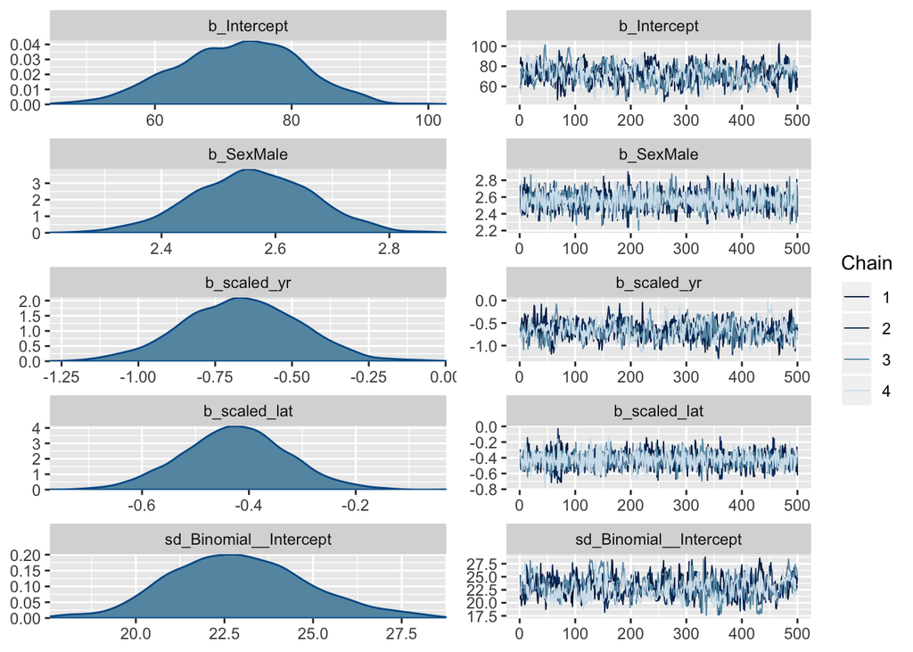

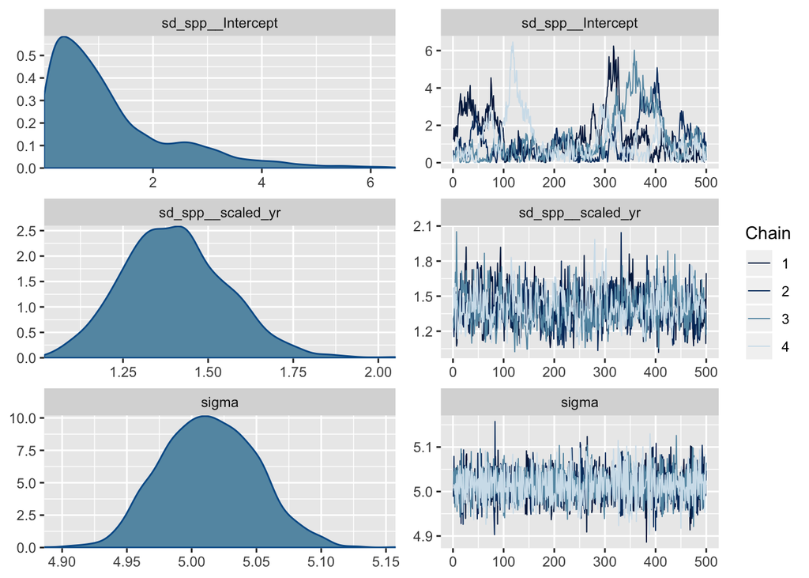

```r
#brms::launch_shinystan(brm0)
plot(brm0)
```

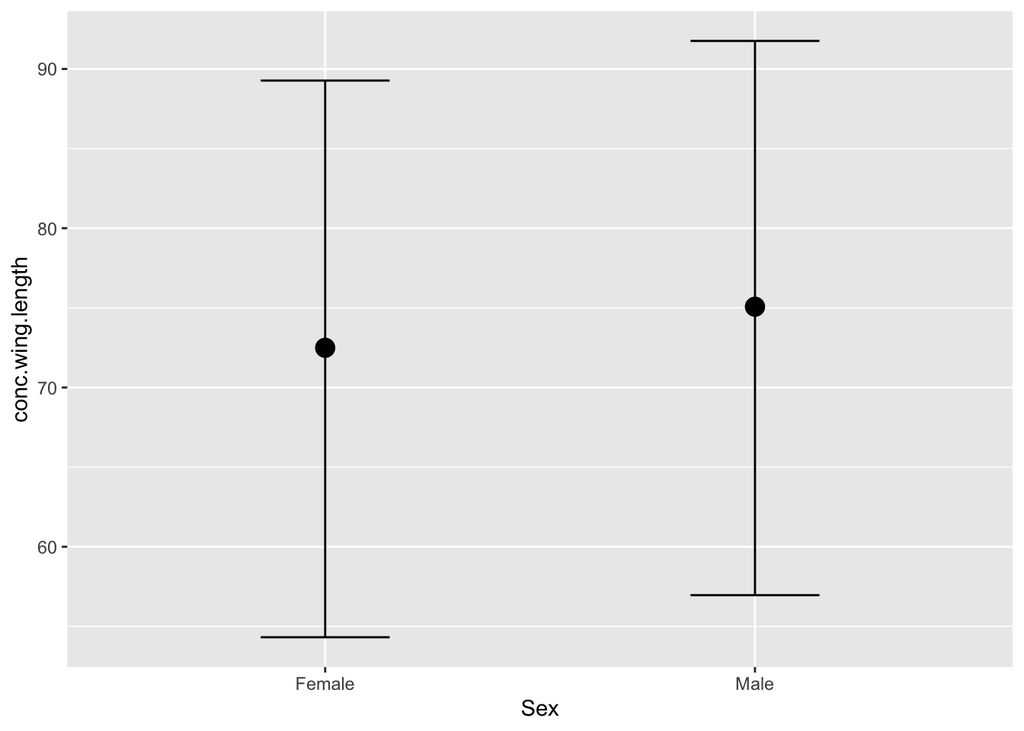

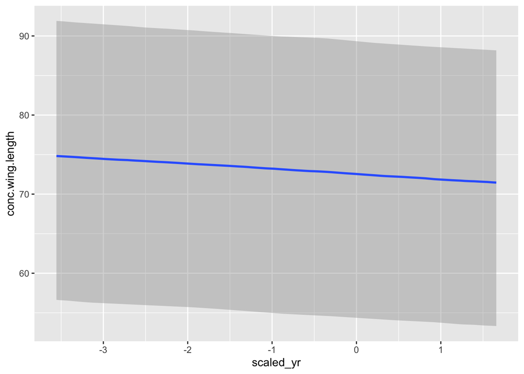

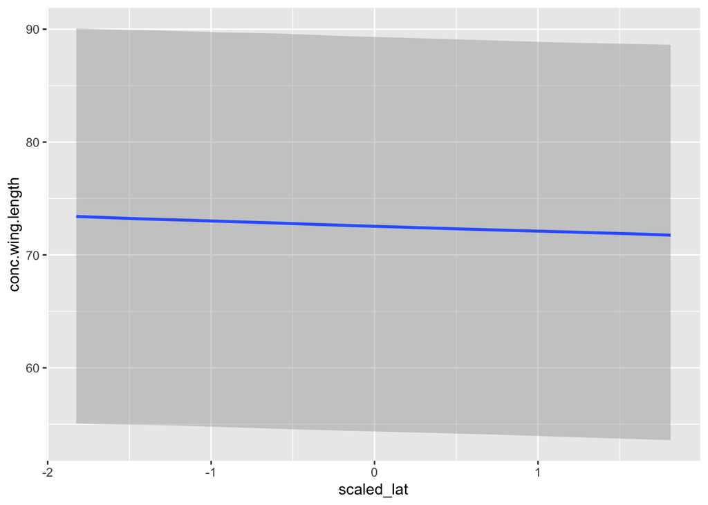

```r
plot(marginal_effects(brm0))
```

```r
pp_check(brm0)
```

```
## Using 10 posterior samples for ppc type 'dens_overlay' by default.
```

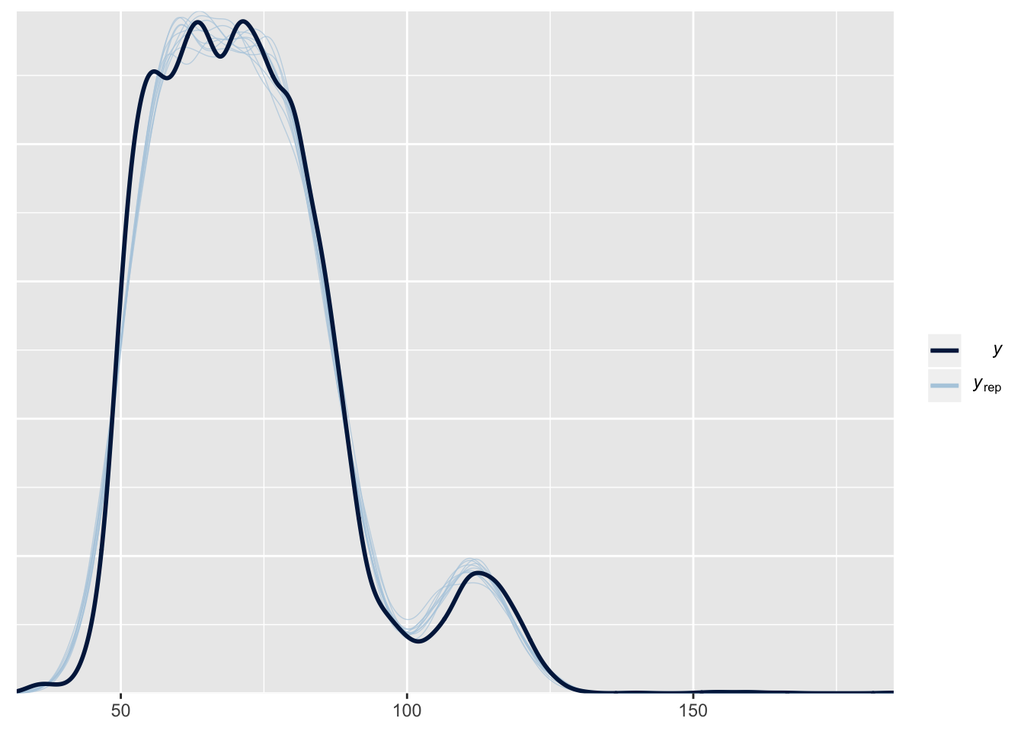

```r
hyp <- "sd_Binomial__Intercept^2 / (sd_Binomial__Intercept^2 + sd_spp__Intercept^2 + sd_spp__scaled_yr^2 + sigma^2) = 0"
(hyp <- hypothesis(brm0, hyp, class = NULL))
```

```
## Hypothesis Tests for class :
##                 Hypothesis Estimate Est.Error CI.Lower CI.Upper Evid.Ratio
## 1 (sd_Binomial__Int... = 0     0.95      0.01     0.91     0.96         NA
##   Post.Prob Star
## 1        NA    *
## ---
## 'CI': 90%-CI for one-sided and 95%-CI for two-sided hypotheses.
## '*': For one-sided hypotheses, the posterior probability exceeds 95%;
## for two-sided hypotheses, the value tested against lies outside the 95%-CI.
## Posterior probabilities of point hypotheses assume equal prior probabilities.
```

## brm model of bill width

I will keep this full model here for a while. I will run the model from the chunk above as a test model with the multiple imputation data.

```r
# Defining the priors to use in the gape model:
prior.gape <- get_prior(Bill_width.mm. ~ 1 + scaled_yr + gp(Longitude_decimal_degrees, Latitude_decimal_degrees, scale = TRUE, gr = TRUE),
                 data = passer90,
                 family = gaussian
                 )
# The model crashes when the prior inv_gamma has shape = 0, thus I changed the shape to 0.1:
prior.gape$prior[5] <- "inv_gamma(0.30912, 0.1)"

start_time <- Sys.time()
brm0.gape <- brm(Bill_width.mm. ~ 1 + scaled_yr + gp(Longitude_decimal_degrees, Latitude_decimal_degrees, scale=TRUE, gr = TRUE),
            data = passer90,
            family = gaussian,
            prior = prior.gape,
            inits = "0",
            iter = 1500,
            warmup = 1000,
            chains = 2,
            cores = 2,
            control = list(max_treedepth = 12)
            )

end_time <- Sys.time();end_time - start_time

save(brm0.gape, file = "brm0.gape.model.rda")
```

Summary and model convergence checks:

```r
load("brm0.gape.model.rda")

summary(brm0.gape)
```

```
##  Family: gaussian
##   Links: mu = identity; sigma = identity
## Formula: Bill_width.mm. ~ 1 + scaled_yr + gp(Longitude_decimal_degrees, Latitude_decimal_degrees, scale = TRUE, gr = TRUE)
##    Data: passer90 (Number of observations: 4232)
## Samples: 2 chains, each with iter = 1500; warmup = 1000; thin = 1;
##          total post-warmup samples = 1000
##
## Gaussian Process Terms:
##                                                             Estimate
## sdgp(gpLongitude_decimal_degreesLatitude_decimal_degrees)       6.33
## lscale(gpLongitude_decimal_degreesLatitude_decimal_degrees)     0.15
##                                                             Est.Error
## sdgp(gpLongitude_decimal_degreesLatitude_decimal_degrees)        4.34
## lscale(gpLongitude_decimal_degreesLatitude_decimal_degrees)      0.15
##                                                             l-95% CI
## sdgp(gpLongitude_decimal_degreesLatitude_decimal_degrees)       1.80
## lscale(gpLongitude_decimal_degreesLatitude_decimal_degrees)     0.00
##                                                             u-95% CI
## sdgp(gpLongitude_decimal_degreesLatitude_decimal_degrees)      10.67
## lscale(gpLongitude_decimal_degreesLatitude_decimal_degrees)     0.30
##                                                             Eff.Sample
## sdgp(gpLongitude_decimal_degreesLatitude_decimal_degrees)            1
## lscale(gpLongitude_decimal_degreesLatitude_decimal_degrees)          1
##                                                               Rhat
## sdgp(gpLongitude_decimal_degreesLatitude_decimal_degrees)    52.82
## lscale(gpLongitude_decimal_degreesLatitude_decimal_degrees) 306.60
##
## Population-Level Effects:
##           Estimate Est.Error l-95% CI u-95% CI Eff.Sample  Rhat
## Intercept     4.30      3.44     0.86     8.06          1 28.73
## scaled_yr     0.38      0.11     0.28     0.59          1  2.74
##
## Family Specific Parameters:
##       Estimate Est.Error l-95% CI u-95% CI Eff.Sample  Rhat
## sigma     2.13      0.26     1.83     2.39          1 18.40
##
## Samples were drawn using sampling(NUTS). For each parameter, Eff.Sample
## is a crude measure of effective sample size, and Rhat is the potential
## scale reduction factor on split chains (at convergence, Rhat = 1).
```

```r
#stanplot(brm0.gape)
#brms::launch_shinystan(brm0)
#plot(brm0.gape)
#plot(marginal_effects(brm0.gape))
#pp_check(brm0.gape, nug = 1e-05)

hyp <- "sd_Binomial__Intercept^2 / (sd_Binomial__Intercept^2 + sd_spp__Intercept^2 + sd_spp__scaled_yr^2 + sigma^2) = 0"
#(hyp <- hypothesis(brm0.gape, hyp, class = NULL))
```

## Multi-level model with phylogenetic uncertainty

```r
load("~/Google Drive/Manuscripts/MyPapers/CurrentlyWorking/2019_atlantic_birds/edu_joao/brm0.rda")

brm_multi_phylo <- combine_models(mlist = brm0)
summary(brm_multi_phylo)
```

```
##  Family: gaussian
##   Links: mu = identity; sigma = identity
## Formula: Wing_length_right.mm. ~ 1 + Sex + scaled_yr + scaled_lat + (1 + scaled_yr || spp) + (1 | Binomial)
##    Data: passer90 (Number of observations: 4629)
## Samples: 56 chains, each with iter = 1500; warmup = 1000; thin = 1;
##          total post-warmup samples = 28000
##
## Group-Level Effects:
## ~Binomial (Number of levels: 68)
##               Estimate Est.Error l-95% CI u-95% CI Eff.Sample Rhat
## sd(Intercept)    20.91      2.02    17.32    25.22        216 1.10
##
## ~spp (Number of levels: 68)
##               Estimate Est.Error l-95% CI u-95% CI Eff.Sample Rhat
## sd(Intercept)     0.81      0.77     0.03     2.88        866 1.06
## sd(scaled_yr)     1.99      0.24     1.57     2.51       7141 1.01
##
## Population-Level Effects:
##            Estimate Est.Error l-95% CI u-95% CI Eff.Sample Rhat
## Intercept     70.68      8.27    54.55    87.07       3080 1.02
## SexMale        2.71      0.12     2.47     2.95      40065 1.00
## scaled_yr     -0.43      0.28    -0.96     0.13       3533 1.01
## scaled_lat    -0.86      0.12    -1.09    -0.62      31338 1.00
##
## Family Specific Parameters:
##       Estimate Est.Error l-95% CI u-95% CI Eff.Sample Rhat
## sigma     3.95      0.04     3.87     4.03      39269 1.00
##
## Samples were drawn using sampling(NUTS). For each parameter, Eff.Sample
## is a crude measure of effective sample size, and Rhat is the potential
## scale reduction factor on split chains (at convergence, Rhat = 1).
```

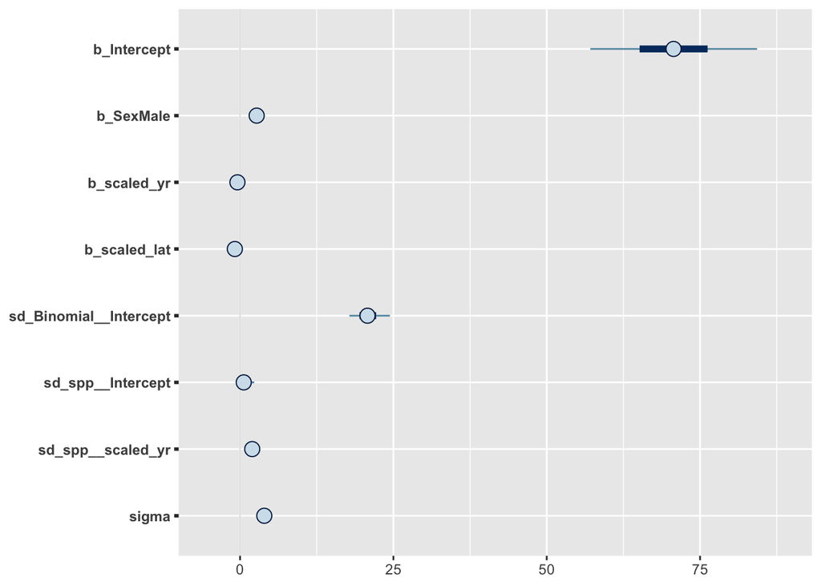

```r
stanplot(brm_multi_phylo)
```

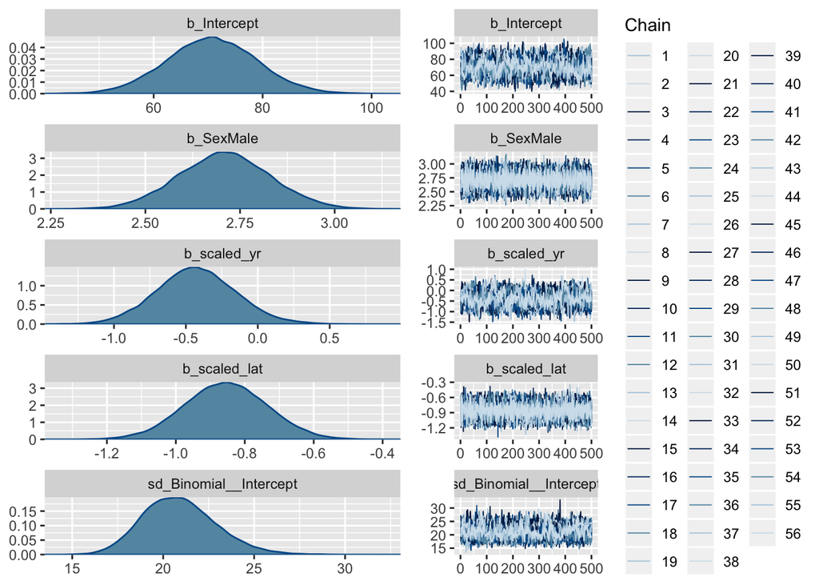

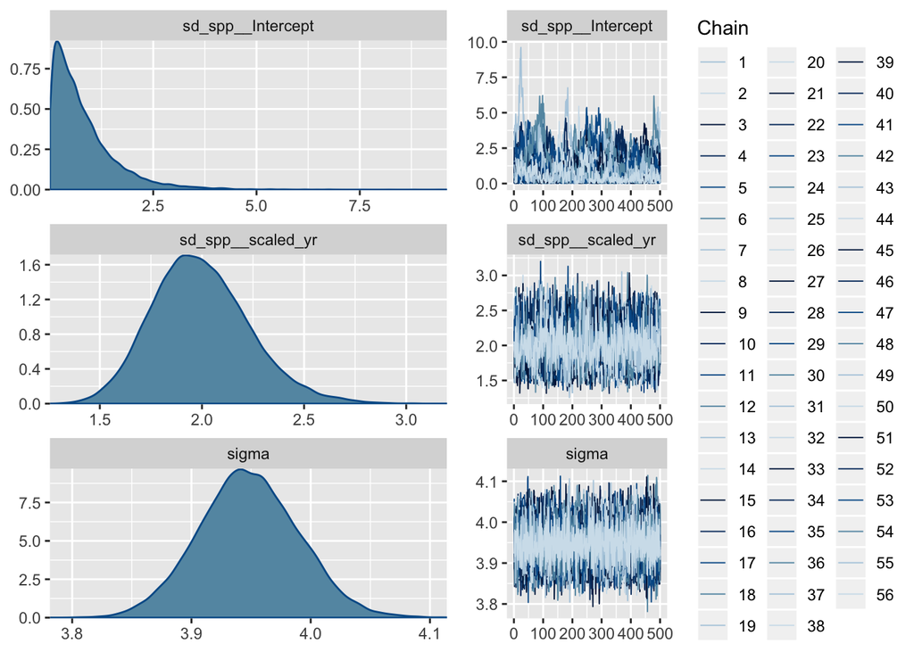

```r
#brms::launch_shinystan(brm0)
plot(brm_multi_phylo)
```

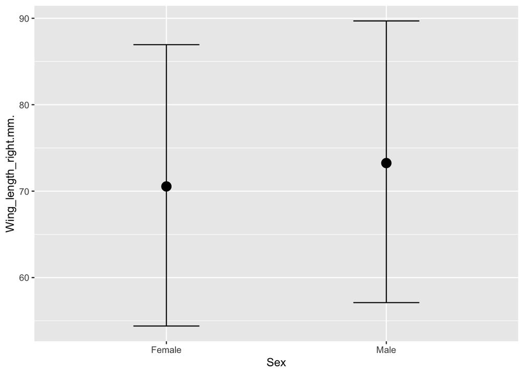

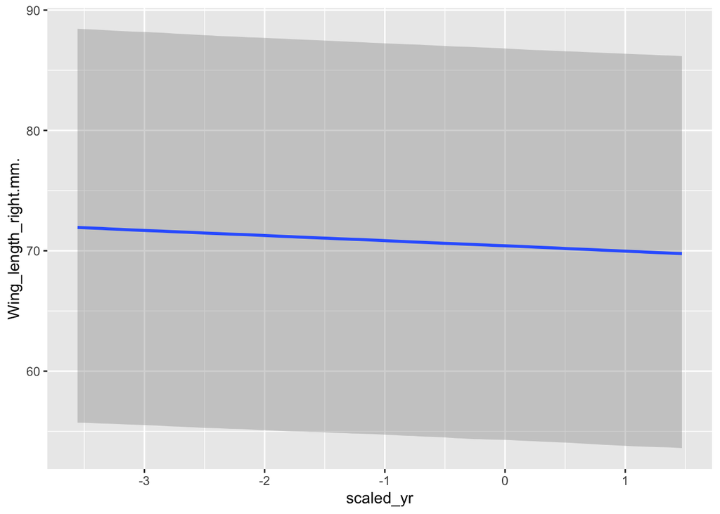

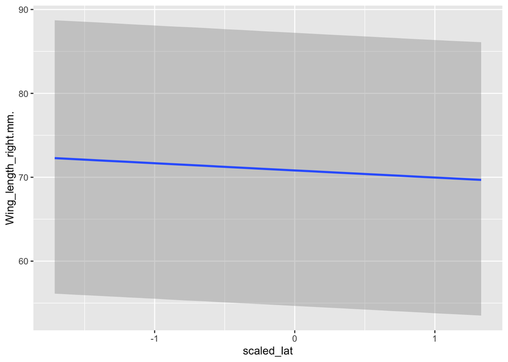

```r
plot(marginal_effects(brm_multi_phylo))
```

```r
pp_check(brm_multi_phylo)
```

```
## Using 10 posterior samples for ppc type 'dens_overlay' by default.
```

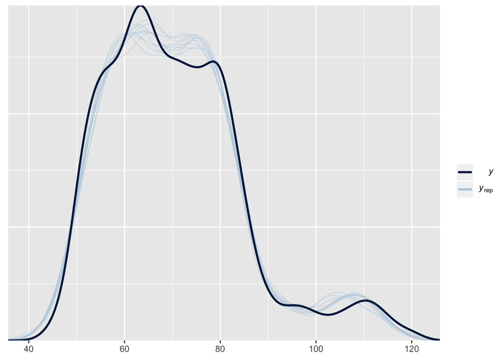

```r
hyp <- "sd_Binomial__Intercept^2 / (sd_Binomial__Intercept^2 + sd_spp__Intercept^2 + sd_spp__scaled_yr^2 + sigma^2) = 0"
(hyp <- hypothesis(brm_multi_phylo, hyp, class = NULL))
```

```
## Hypothesis Tests for class :
##                 Hypothesis Estimate Est.Error CI.Lower CI.Upper Evid.Ratio
## 1 (sd_Binomial__Int... = 0     0.95      0.01     0.93     0.97         NA
##   Post.Prob Star
## 1        NA    *
## ---
## 'CI': 90%-CI for one-sided and 95%-CI for two-sided hypotheses.
## '*': For one-sided hypotheses, the posterior probability exceeds 95%;
## for two-sided hypotheses, the value tested against lies outside the 95%-CI.
## Posterior probabilities of point hypotheses assume equal prior probabilities.
```

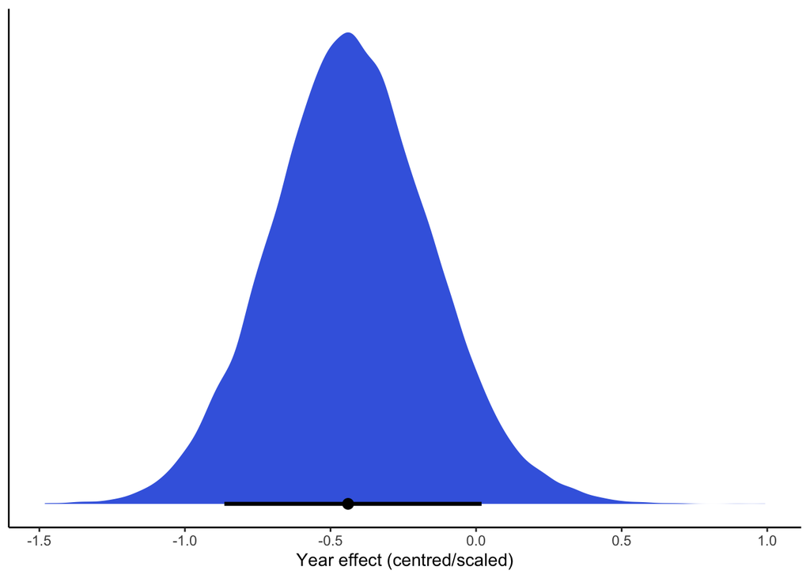

```r
post <- posterior_samples(brm_multi_phylo)

beta_yr_ef <-
  post %>%
  transmute(beta_yr_ef = b_scaled_yr)

require("tidybayes")

beta_yr_ef %>%
  ggplot(aes(x = beta_yr_ef)) +
  geom_density(size = 0, fill = "royalblue") +
  stat_pointintervalh(aes(y = 0),
                      point_interval = mode_hdi, .width = .89) +
  scale_y_continuous(NULL, breaks = NULL) +
  labs(x = "Year effect (centred/scaled)") +
  theme_classic()
```

```r
start_time <- Sys.time()
brm1 <- brm(Body_mass.g. ~ 1 + Sex + scaled_yr + scaled_lat + (1 + scaled_yr || spp) + (1 | Binomial),
            cov_ranef = list(Binomial = A),
            data = passer90,
            family = gaussian,
            prior = c(prior(normal(71, 15), class = Intercept),
                      prior(normal(0, 10), class = b),
                      prior(cauchy(0, 1), class = sd),
                      prior(cauchy(0, 1), class = sigma)),
            iter = 2000,
            warmup = 1000,
            chains = 3,
            cores = 3,
            control = list(max_treedepth = 12))

end_time <- Sys.time();end_time - start_time

summary(brm1)
stanplot(brm1)
#brms::launch_shinystan(brm0)

plot(marginal_effects(brm1), points = TRUE)
pp_check(brm1)

hyp <- "sd_Binomial__Intercept^2 / (sd_Binomial__Intercept^2 + sd_spp__Intercept^2 + sigma^2) = 0"
(hyp <- hypothesis(brm1, hyp, class = NULL))
```

# Arthropod abundance over time analysis

I wanted to look for a dataset that contained information on the abundance of arthropods in Brazil (more specifically, if available, in the Atlantic Forest) over time. The idea being that we could use this information as part of the argument that what we are observing for the birds is in fact being caused by a decline in the abundance of their food source over time. Thus, we have a signature of a phenotypic plasticity process at hand, and not a micro-evolutionary response.

I found the PREDICTS project (Hudson et al. 2017), which has collated a huge amount of biodiversity data per locality, with more than 3.2 million records. I downloaded the main database (**/Volumes/Macintosh HD/Users/eduardosantos/Downloads/database.csv**) and then proceeded to wrangle the data to obtain records for Arachnida and Insecta for whole Brazil:

```r
dat <- read_csv("/Volumes/Macintosh HD/Users/eduardosantos/Downloads/database.csv", guess_max = 70000)
```

```r
# Playing with data from WHOLE Brazil to see what is going on:
dat_test <- dat %>%
        filter(Phylum == "Arthropoda", Diversity_metric_type == "Abundance", UN_subregion == "South America", Class %in% c("Insecta", "Arachnida")) %>%
        mutate(
          scaled_yr = as.numeric(scale(Sample_midpoint)),
          log_abundance = log(Effort_corrected_measurement),
          Measurement = as.integer(Measurement),
          Class = as.factor(Class)
) # I logged the abundance divided by sampling effort in order to normalize the data

rm("dat")
save(dat_test, file = "dat_test.rds")
```

Loading the subset of South America data that I had already saved as a .rds file

```r
load("dat_test.rds")

dat_test <- dat_test %>%
      mutate(
        Class = as.factor(Class),
        log_sampling = log(Sampling_effort) # logging sampling effort to use as offset in Poisson model
        )
```

Plotting the relationship between year and abundance of arthropods in Brazil.

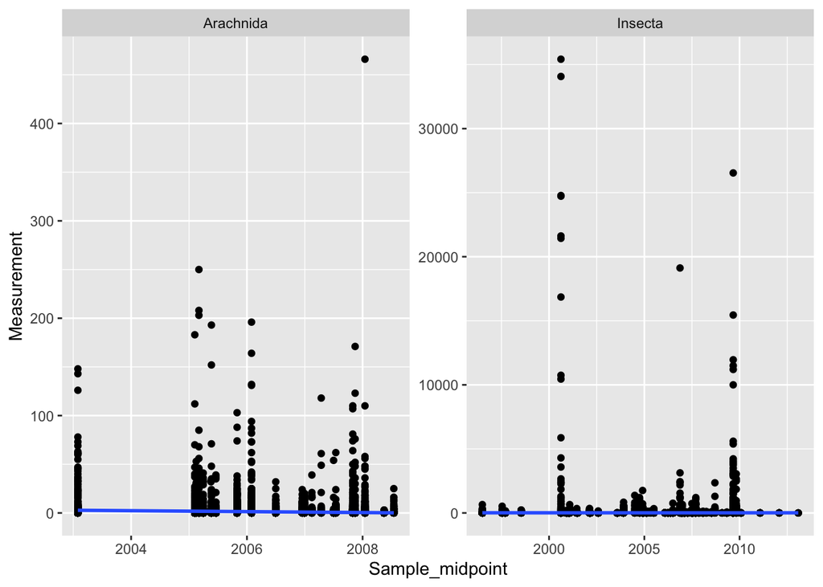

```r
g_test <-  ggplot(data = dat_test, aes(x = Sample_midpoint, y = Measurement)) +
                  geom_point() +
                  stat_smooth(method = "lm", se = FALSE) +
                  facet_wrap(~Class, scales = "free")

g_test
```

## Arthropod abundance brm model

Negative binomial model with offset to investigate the relationship between the predictor **year** and the response (count) abundance of arthropods in Brazil.

```r
start_time <- Sys.time()
brm1 <-
  brm(data = dat_test, family = negbinomial,
      Measurement ~ 1 + offset(log_sampling) + scaled_yr,
      prior = c(prior(normal(0, 10), class = Intercept),
                prior(normal(0, 1), class = b),
                prior(gamma(0.01, 0.01), class = shape) # the brms default
                ),
      cores = 2,
      chains = 2,
      iter = 1000)
end_time <- Sys.time();end_time - start_time
```

```
## Time difference of 4.724926 mins
```

```r
save(brm1, file = "brm_arthro_abund.rda")
```

Loading arthropod abundance model to check summary and convergence.

```r
load("brm_arthro_abund.rda")

summary(brm1)
```

```
##  Family: negbinomial
##   Links: mu = log; shape = identity
## Formula: Measurement ~ 1 + offset(log_sampling) + scaled_yr
##    Data: dat_test (Number of observations: 76471)
## Samples: 2 chains, each with iter = 1000; warmup = 500; thin = 1;
##          total post-warmup samples = 1000
##
## Population-Level Effects:
##           Estimate Est.Error l-95% CI u-95% CI Eff.Sample Rhat
## Intercept    -0.65      0.02    -0.68    -0.61        695 1.00
## scaled_yr    -0.25      0.02    -0.29    -0.22        776 1.00
##
## Family Specific Parameters:
##       Estimate Est.Error l-95% CI u-95% CI Eff.Sample Rhat
## shape     0.05      0.00     0.04     0.05       1160 1.00
##
## Samples were drawn using sampling(NUTS). For each parameter, Eff.Sample
## is a crude measure of effective sample size, and Rhat is the potential
## scale reduction factor on split chains (at convergence, Rhat = 1).
```

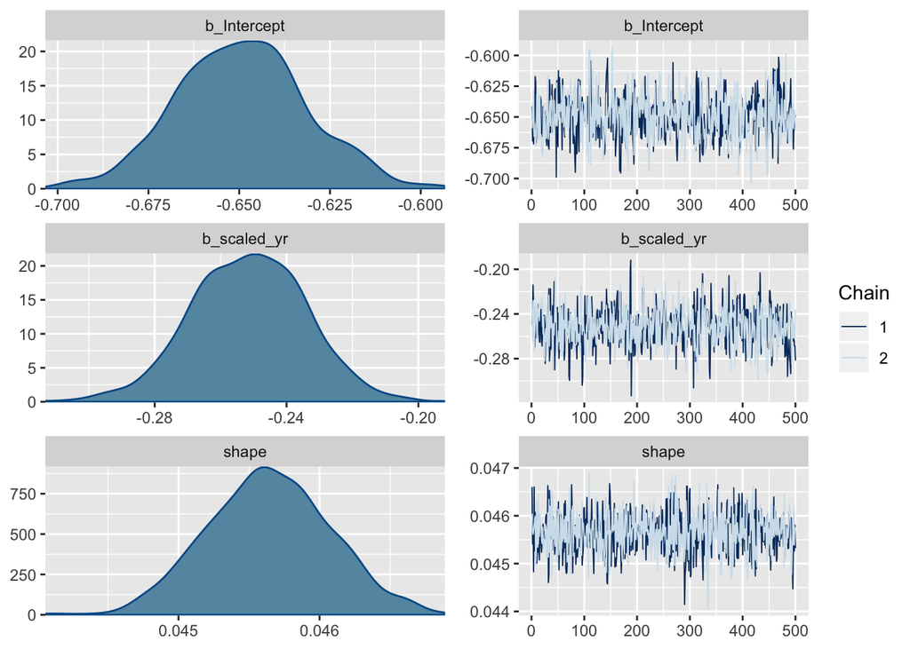

```r
plot(brm1)
```

```r
fixef(brm1)[1:2, ] %>%
  exp()
```

```
##            Estimate Est.Error      Q2.5     Q97.5
## Intercept 0.5224321  1.018159 0.5049983 0.5414491
## scaled_yr 0.7775828  1.017474 0.7510957 0.8040992
```

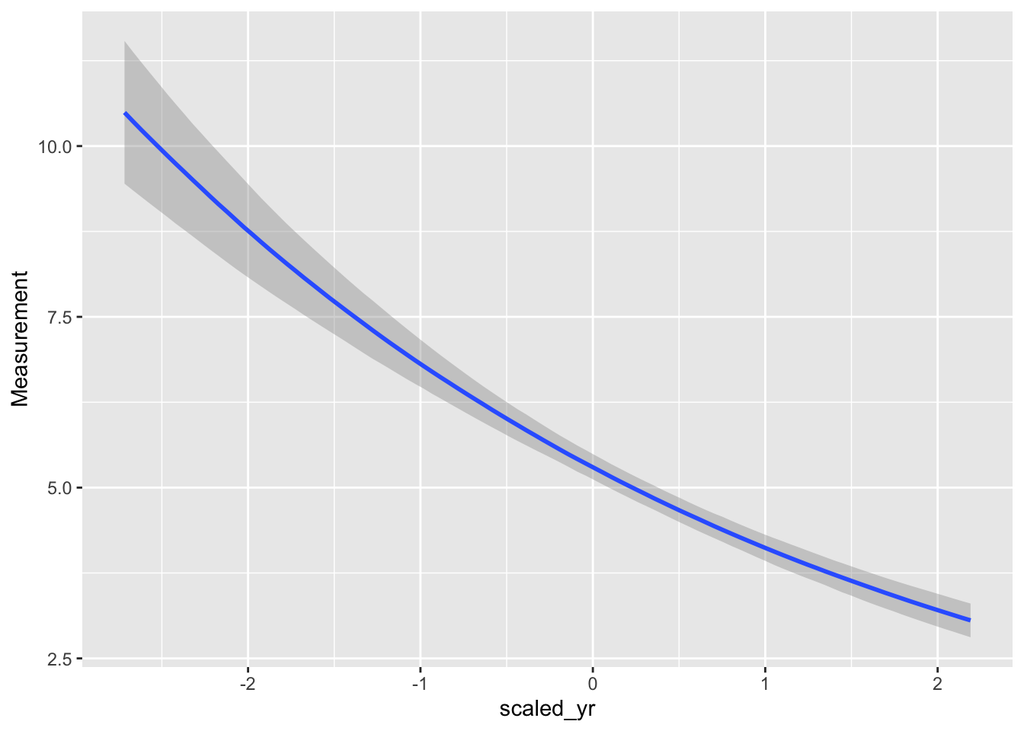

```r
plot(marginal_effects(brm1))
```

```r
pp_check(brm1)
```

```
## Using 10 posterior samples for ppc type 'dens_overlay' by default.
```

[figure not shown]

Glauco has rightfully suggested that I removed ants from the abundance dataset to see how sensitive it is to these arthropods. Birds are not known to predate ants, thus it makes sense to run the analyses without ants. Negative binomial model with offset to investigate the relationship between the predictor **year** and the response (count) abundance of arthropods in Brazil.

```r
dat_no_ants <- dat_test %>%
        filter(Family != "Formicidae"
               )

save(dat_no_ants, file = "dat_no_ants.rds")
```

Model with no ant abundance:

```r
start_time <- Sys.time()
brm_no_ants <-
  brm(data = dat_no_ants, family = negbinomial,
      Measurement ~ 1 + offset(log_sampling) + scaled_yr,
      prior = c(prior(normal(0, 10), class = Intercept),
                prior(normal(0, 1), class = b),
                prior(gamma(0.01, 0.01), class = shape) # the brms default
                ),
      cores = 2,
      chains = 2,
      iter = 1000)
end_time <- Sys.time();end_time - start_time
```

```
## Time difference of 2.781375 mins
```